# Part 3 - ZNZ

2021-07-08 (updated: 2022-03-14)

# R as a programmable calculator

R can perform calculations for you and return an answer. For example:

```r
3+8+4
```

```
## [1] 15
```

```r
log10(pi^4 / sqrt(5))
```

```
## [1] 1.639114
```

```r
17 == 3+8+4
```

```
## [1] FALSE
```

Note, here again, the use of the double equal in the third example above, rather than just ‘=’. While the single ‘=’ is reserved for assigning values to variables, the double ‘==’ tells R to evaluate whether the two things on either side are indeed equal, and returns a logical value (i.e. TRUE / FALSE). You could also assign the answer from your calculation to a variable. In this case, the answer will not be displayed straight away, but will be stored in memory.

```r
VariableB <- 3+8+4; VariableB
```

```
## [1] 15
```

A great feature of R is that calculations can be performed for many values at the same time. Let’s combine what we learned about accessing sub-elements of vectors, data frames and matrices with some simple calculations and functions.

We’ll start with an operation involving a vector

```r
MyVector
```

```
## [1] "hello!"   "goodbye!" "3.14"     "2016"     "FALSE"
```

```r
nchar(MyVector)
```

```
## [1] 6 8 4 4 5
```

> Note: ‘nchar’ is a function that calculates the number of characters in a string. See ?nchar for details.

Now let’s look first at applying mathematical operations to matrix objects.

```r
MyMatrix
```

```
##    A B C D
## I  1 3 5 7
## II 2 4 6 8
```

```r
log10(MyMatrix)
```

```
##          A         B         C        D
## I  0.00000 0.4771213 0.6989700 0.845098
## II 0.30103 0.6020600 0.7781513 0.903090
```

```r
MyMatrix/2
```

```
##      A   B   C   D
## I  0.5 1.5 2.5 3.5
## II 1.0 2.0 3.0 4.0
```

```r
apply(X=MyMatrix, MARGIN=2, sum)
```

```
##  A  B  C  D
##  3  7 11 15
```

> Note: ‘apply’ is a function that allows us to apply other functions across elements of a matrix. See ?apply for details.

So, as you see, we can call up objects, or their elements, and use them in mathematical expressions

```r
MyList$Second.Element$First.Variable
```

```
## [1] 101 102 103 104 105 106 107 108
```

```r
MyMatrix * MyList$Second.Element$First.Variable / MyMatrix[1,2]
```

```
##           A        B   C        D
## I  33.66667 103.0000 175 249.6667
## II 68.00000 138.6667 212 288.0000
```

```r
MyDataFrame
```

```
##   First.Variable Second.Variable Third.Variable Yet.Another.Variable
## 1            101              Do           TRUE             3.000000
## 2            102              Ra          FALSE             3.142857
## 3            103              Mi           TRUE             3.285714
## 4            104              Fa          FALSE             3.428571
## 5            105              So           TRUE             3.571429
## 6            106              La          FALSE             3.714286
## 7            107              Ti           TRUE             3.857143
## 8            108              Do          FALSE             4.000000
```

```r
trunc(MyDataFrame$Yet.Another.Variable)
```

```
## [1] 3 3 3 3 3 3 3 4
```

> Note: ‘trunc’ is a function that strips away everything after the decimal. See ?trunc for more details.

```r
sapply(X=MyDataFrame[,4], FUN=trunc)
```

```
## [1] 3 3 3 3 3 3 3 4
```

Here we obtain the same result as in the call above, still using the function ‘trunc’; however, the syntax we used to apply this function was different. Specifically, we used ‘sapply’, a function that allows us to apply other functions to each element (i.e. column) of a data frame. Note the similarity to ‘apply’, which was introduced above. Let’s see another example using ‘sapply’:

```r
sapply(X=MyDataFrame[,c(1,4)], FUN=mean)
```

```
##       First.Variable Yet.Another.Variable
##                104.5                  3.5
```

In the code below, we continue work with our ‘MyDataFrame’ object and the ‘trunc’ function, but we also go a little further in that we immediately use the output from this function in further operations. Specifically, we ask where and how this truncation has changed things.

```r
MyDataFrame$Yet.Another.Variable
```

```
## [1] 3.000000 3.142857 3.285714 3.428571 3.571429 3.714286 3.857143 4.000000
```

```r
MyDataFrame$Yet.Another.Variable == trunc(MyDataFrame$Yet.Another.Variable)
```

```
## [1]  TRUE FALSE FALSE FALSE FALSE FALSE FALSE  TRUE
```

```r
MyDataFrame$Yet.Another.Variable[MyDataFrame[[4]] == sapply(X=MyDataFrame[,4], FUN=trunc)]
```

```
## [1] 3 4
```

```r
which(MyDataFrame[[4]] == sapply(X=MyDataFrame[,4], FUN=trunc))
```

```
## [1] 1 8
```

Do you understand why the last two of the above commands give different output?

Just for interest, below are some more handy functions related to truncating, rounding, etc. In the last two commands, we use the ‘integer division’ and ‘modulus’ arithmetic operators.

```r
trunc(MyDataFrame$Yet.Another.Variable)
```

```
## [1] 3 3 3 3 3 3 3 4
```

```r
round(MyDataFrame$Yet.Another.Variable)
```

```
## [1] 3 3 3 3 4 4 4 4
```

```r
ceiling(MyDataFrame$Yet.Another.Variable)
```

```
## [1] 3 4 4 4 4 4 4 4
```

```r
floor(MyDataFrame$Yet.Another.Variable)
```

```
## [1] 3 3 3 3 3 3 3 4
```

```r
MyDataFrame$Yet.Another.Variable %/% 1
```

```
## [1] 3 3 3 3 3 3 3 4
```

```r
MyDataFrame$Yet.Another.Variable %% 3
```

```
## [1] 0.0000000 0.1428571 0.2857143 0.4285714 0.5714286 0.7142857 0.8571429
## [8] 1.0000000
```

# Exercise 3

Take a look at yet another sample dataset: ‘islands’. See ‘?islands’ for details.

3.1 What is the cumulative total area of these landmasses?

3.2 Express all values of ‘islands’ as proportions.

Now let’s work with the dataset ‘women’. See ‘?women’.

3.3 Knowing that body-mass-index, or ‘BMI’ = mass_kg / (height_m)^2 = (mass_pounds / (height_inches)^2) * 703, calculate which of the women in the dataset has the highest BMI.

> Feel free to play with any of the datasets you can find with ‘data()’ to further develop your competence in handling and manipulating objects, and performing basic calculations with whole objects, subsets of objects, or individual elements.

# Working with standard statistical distributions

Distributions are fundamental to statistics. Many types of data will, in sufficiently-sized samples, start to form recognizable distributions. For example, if we collected measurements of many people’s heights, and constructed a histogram from these measures, we should see a bell-shaped pattern - i.e. the normal, or Gaussian, distribution. Test statistics too tend to form recognizible distributions. For example, if we calculated chi-squared statistics from counts in a series of crosstabulation tables, a histogram of these chi-squared values should have a familiar right-skewed distribution of positive values. Statisticians have long studied these and other standard distributions and have developed formulae to describe their shapes and characteristics. So, if we know the underlying distribution of our data / test-statistics we can use these formulae to derive inferences about them. R’s “stats” package (part of the default installation) includes formulae for many of the most common distributions.

```r
?Distributions
```

For each distribution, functions are provided that calculate for us the probability density or cumulative distribution functions, given essential parameters as input. We can also specify a distribution, and get R to return quantiles or randomly generated numbers from this distribution.

Let’s see how this works. We’ll start with the normal distribution. This distribution has two characteristic features: mean (i.e. where the peak of the “bell” is situated, along the x axis), and standard deviation (i.e. how broad is the bell-shape, along the x-axis).

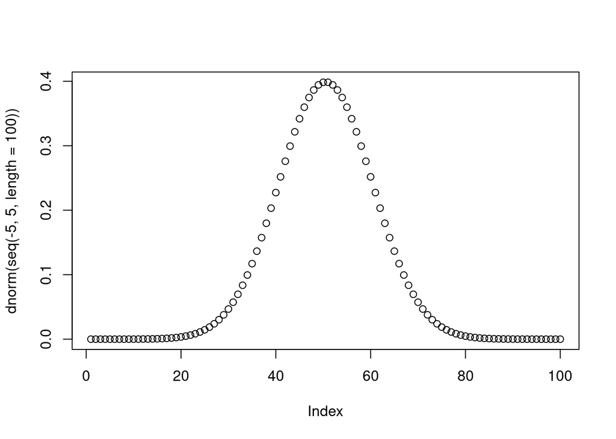

```r
plot(dnorm(seq(-5,5,length=100)))
```

```r
dnorm(x = c(152.4, 182.88, 213.36), mean = 183.8, sd = 7.1)
```

```
## [1] 3.180595e-06 5.571931e-02 9.675622e-06
```

In the line above, we specified a normal distribution centred around 183.8 (the average height of Dutch men, according to http://www.nature.com/pr/journal/v73/n3/full/pr2012189a.html), with a standard deviation of 7.1. We used the dnorm function to calculate the y value of the normal function at some specific x value. In this case, we asked R to calculate the height of the “bell” when x is, respectively, 152.4, 182.88, or 213.36 cm (= 5, 6 or 7 ft).

We might be tempted to think of these values as probabilities - i.e. the chances of a Dutch man’s height being exactly 152.4, 182.88, or 213.36 respectively. However, this is not so. Imagine: if we could measure height with infinite precision, the probability of obtaining exactly 152.400000000 (or any number, in fact!) would approach zero. Instead, it helps to think about ranges of values…

```r
pnorm(q = c(152.4, 182.88, 213.36), mean = 183.8, sd = 7.1)
```

```
## [1] 4.877472e-06 4.484504e-01 9.999843e-01
```

With the cumulative distribution function, we can now interpret the numbers as probabilities. Specifically, they are the probability of obtaining (by random sampling from the distribution we’ve defined) values up to 152.4, 182.88, or 213.36 cm respectively. So… if we want the probability of encountering a Dutch man under 5ft in height:

```r
pnorm(q = 152.4, mean = 183.8, sd = 7.1)
```

```
## [1] 4.877472e-06
```

… or over 7ft tall:

```r
1 - pnorm(q = 213.36, mean = 183.8, sd = 7.1)
```

```
## [1] 1.567852e-05
```

```r
pnorm(q = 213.36, mean = 183.8, sd = 7.1, lower.tail=F)
```

```
## [1] 1.567852e-05
```

```r
ppois(q = .5, lambda = 1, lower.tail = T) + ppois(q = .5, lambda = 1, lower.tail = F)
```

```
## [1] 1
```

Or shorter than your average Aymaran Bolivian (~160 cm):

```r
pnorm(q = 160, mean = 183.8, sd = 7.1)
```

```
## [1] 0.0004009869
```

The quantile function does things the other way round. We specify which probabilities we are interested in, and we get the threshold x values corresponding to these probabilities:

```r
qnorm(p = c(0.05, 0.95), mean = 183.8, sd = 7.1)
```

```
## [1] 172.1215 195.4785
```

Thus, the shortest 5% of Dutch men are shorter than 172.12 cm, while the tallest 5% are over 195.48

The random number generator is very useful - for instance if we want to simulate some data drawn from some particular distribution. In the code below, we once again use the published estimates for the mean and standard deviation of heights of Dutch men, and now we draw a random sample of 1000 imaginary Dutch men from a normal distribution having these characteristics. Run the code below a few times to see what happens.

```r
testdata <- rnorm(n = 1000, mean = 183.8, sd = 7.1); summary(testdata)
```

```
##    Min. 1st Qu.  Median    Mean 3rd Qu.    Max.
##   163.5   179.3   184.0   184.0   189.0   204.5
```

Actually… now that we’ve encountered a situation where we want to run a piece of code repeatedly, perhaps its a good opportunity to show how we can do this in a more automated way in R. Here’s one approach:

```r
replicate(n = 10, summary(rnorm(n = 1000, mean = 183.8, sd = 7.1)))
```

```
##             [,1]     [,2]     [,3]     [,4]     [,5]     [,6]     [,7]     [,8]
## Min.    157.9395 158.5250 154.8426 155.4332 162.5010 160.5520 162.7719 163.9481
## 1st Qu. 178.9228 179.0690 179.1147 178.9863 178.4151 178.7630 179.1135 178.9158
## Median  183.2008 183.9855 183.8797 183.7790 183.9716 183.2131 183.8185 183.5220
## Mean    183.4193 183.9905 183.7864 183.7165 183.7332 183.5203 183.8228 183.6215
## 3rd Qu. 188.4157 188.9192 188.5720 188.5087 188.8699 188.1221 188.5082 188.1423
## Max.    206.6018 204.2543 203.4886 210.3852 206.5472 203.9518 210.1739 207.0689
##             [,9]    [,10]
## Min.    160.2012 161.9208
## 1st Qu. 179.3032 179.1933
## Median  183.8474 183.9816
## Mean    183.7970 183.9723
## 3rd Qu. 188.5847 188.8119
## Max.    204.1157 202.2379
```

## Exercise 4

4.1 Create a vector of 30 values, sampled with uniform probability between 0 and 5. (Hint: see ?runif)

4.2 Find the 2.5 and 97.5% quantiles from a standardized normal distribution (i.e. where mean = 0 and sd = 1).

4.3 The Student’s t-distribution has a similar shape to the normal distribution, but, unlike the normal distribution, it is sensitive to the sample size, and flattens out a bit when samples are small. The t-distribution underlies the famous t-test. Assuming a sample of n = 10 values, use function ‘qt’ (see ?TDist) to find the lower and upper quantiles, symmetrical about the mean, that contain 95% of all values.

4.4 In a random sample from the t-distribution of n = 30 values, what are the chances of obtaining a t at least as large as 2?

4.5 In a class of 23 students, what are the chances that two students share the same birthday? (Hint: R’s default installation includes a less common type of test-statistic distribution that is particularly well suited to this problem. Search the help!, use pbirthday)

# Writing your own custom functions

In this tutorial so far we have already encountered a number of different R functions, like ‘mean’, ‘log’, ‘trunc’, ‘nchar’, ‘rnorm’, ‘apply’, etc.

One of the things that makes R so powerful, however, is that it is not simply a collection of pre-existing functions, but … it is a flexible programming language! So, we can also write our own custom functions, which could do all sorts of things, like perform a series of calculations and return an output based on these calculations.

Let’s look at the basic anatomy of a function. First, we must assign our function a name, otherwise it will be single use - we won’t be able to refer to it later on. Next, note that functions can take (named) input arguments, which should be specified within round brackets. Default values can be set for these input variables. A second set of brackets - curly brackets - contains the code describing any computation we want the function to undertake, which may use these input arguments and/or any objects already defined in the working environment.

```r
MyFirstFunction <- function(InputVar1 = 1) {
  sqrt(InputVar1) + (InputVar1)^2
}
```

We can now call this function. We can stipulate whatever values we want as its input arguments…

```r
MyFirstFunction(InputVar1 = 10)
```

```
## [1] 103.1623
```

```r
MyFirstFunction(InputVar1 = 1:10)
```

```
##  [1]   2.000000   5.414214  10.732051  18.000000  27.236068  38.449490
##  [7]  51.645751  66.828427  84.000000 103.162278
```

…or we can just use the default values we set when we defined the function

```r
MyFirstFunction()
```

```
## [1] 2
```

Any objects created within the function exist only in this temporary environment. Once the function has finished executing, the objects are no longer accessible.

```r
InputVar1
```

Functions can take multiple input variables, and the computations performed can be as complex and lengthy as you like. However, remember this: by default, only the last object handled within the function (even if unnamed) is returned to the working directory when the function finishes running. If we want to keep something from earlier in the function, we can use ‘return’. Run the code chunk below, and then rerun them with the hash symbol deleted. Do you understand why SavedValue returns something different in each case?

```r
MySecondFunction <- function(In1, In2)
{ TemporaryVar1 <- MyFirstFunction(In1)
  TemporaryVar1 <- TemporaryVar1 * trunc(In2)
  TemporaryVar2 <- mean(runif(20,0,1))
  Output <- TemporaryVar2 / TemporaryVar1
  print("Calculation finished")
   # return(Output)
}
SavedValue <- MySecondFunction(17,42)
```

```
## [1] "Calculation finished"
```

```r
SavedValue
```

```
## [1] "Calculation finished"
```

## Essentials of programming: logical operators and conditional gates

At the start of this tutorial, we saw that R data types include quantitative and qualitative forms. Qualitative variables - particularly logical TRUE/FALSE variables - can come in very handy when building functions. For instance, consider this command, which tests whether some input is numeric or not:

```r
is.numeric(5)
```

```
## [1] TRUE
```

```r
is.numeric("Cheese")
```

```
## [1] FALSE
```

To build robust and flexible functions, we might need to include some sort of internal error-checking (e.g. “Were values entered for input arguments of the data type?”) and may involve some “gates” to control which bits of code are run, and when (e.g. “Did any of the iterations of a sub-loop return an error? If so, don’t continue, but stop the function here and spit out thie error message.”).

Let’s take a look at how to work with logical operators. To start, let’s make a vector, named ‘x’, 200 elements long, which we’ll randomly populate with logical values (i.e. TRUE or FALSE).

```r
x <- runif(200,min = -1, max = 1) > 0
x
```

```
##   [1] FALSE  TRUE FALSE FALSE  TRUE FALSE FALSE FALSE FALSE FALSE  TRUE FALSE
##  [13]  TRUE FALSE  TRUE FALSE FALSE FALSE FALSE  TRUE FALSE FALSE FALSE  TRUE
##  [25]  TRUE FALSE FALSE  TRUE  TRUE FALSE FALSE FALSE FALSE  TRUE FALSE  TRUE
##  [37]  TRUE FALSE  TRUE FALSE  TRUE  TRUE FALSE  TRUE FALSE FALSE  TRUE FALSE
##  [49] FALSE  TRUE FALSE FALSE  TRUE FALSE  TRUE  TRUE FALSE FALSE FALSE FALSE
##  [61]  TRUE  TRUE  TRUE FALSE FALSE FALSE FALSE FALSE FALSE  TRUE  TRUE FALSE
##  [73]  TRUE FALSE  TRUE FALSE FALSE  TRUE  TRUE  TRUE  TRUE  TRUE  TRUE FALSE
##  [85] FALSE FALSE FALSE FALSE FALSE FALSE FALSE FALSE FALSE FALSE  TRUE FALSE
##  [97]  TRUE  TRUE FALSE FALSE FALSE FALSE FALSE  TRUE FALSE  TRUE FALSE FALSE
## [109] FALSE  TRUE  TRUE  TRUE  TRUE  TRUE FALSE FALSE  TRUE FALSE FALSE  TRUE
## [121] FALSE FALSE  TRUE FALSE FALSE FALSE  TRUE FALSE  TRUE FALSE FALSE FALSE
## [133] FALSE  TRUE  TRUE FALSE  TRUE FALSE  TRUE FALSE  TRUE  TRUE  TRUE FALSE
## [145] FALSE FALSE FALSE  TRUE FALSE  TRUE FALSE FALSE  TRUE FALSE FALSE  TRUE
## [157] FALSE FALSE  TRUE  TRUE FALSE  TRUE  TRUE  TRUE FALSE  TRUE FALSE FALSE
## [169]  TRUE FALSE  TRUE FALSE FALSE FALSE  TRUE  TRUE FALSE  TRUE FALSE FALSE
## [181] FALSE FALSE FALSE  TRUE  TRUE FALSE FALSE  TRUE  TRUE  TRUE  TRUE FALSE
## [193]  TRUE FALSE FALSE FALSE  TRUE FALSE FALSE FALSE
```

Here’s another way we could have made such a vector:

```r
x <- sample(x = c(T,F), size=200, replace = T)
```

How many of each value (i.e. TRUE or FALSE) does your vector x contain?

```r
x==TRUE
```

```
##   [1]  TRUE FALSE  TRUE FALSE FALSE  TRUE FALSE FALSE FALSE FALSE FALSE  TRUE
##  [13] FALSE FALSE  TRUE  TRUE  TRUE  TRUE FALSE  TRUE  TRUE FALSE  TRUE  TRUE
##  [25]  TRUE FALSE FALSE FALSE  TRUE  TRUE FALSE  TRUE  TRUE  TRUE  TRUE FALSE
##  [37]  TRUE  TRUE  TRUE  TRUE  TRUE  TRUE FALSE FALSE FALSE FALSE  TRUE FALSE
##  [49]  TRUE FALSE FALSE FALSE FALSE FALSE FALSE FALSE  TRUE  TRUE  TRUE  TRUE
##  [61]  TRUE  TRUE FALSE  TRUE FALSE  TRUE  TRUE FALSE  TRUE  TRUE  TRUE FALSE
##  [73] FALSE FALSE  TRUE  TRUE  TRUE FALSE FALSE FALSE  TRUE  TRUE FALSE FALSE
##  [85]  TRUE FALSE FALSE  TRUE FALSE  TRUE  TRUE FALSE  TRUE FALSE FALSE  TRUE
##  [97] FALSE  TRUE FALSE FALSE FALSE  TRUE FALSE FALSE FALSE  TRUE  TRUE FALSE
## [109] FALSE FALSE FALSE FALSE FALSE FALSE  TRUE  TRUE  TRUE  TRUE FALSE FALSE
## [121]  TRUE  TRUE FALSE  TRUE FALSE FALSE  TRUE  TRUE  TRUE  TRUE  TRUE  TRUE
## [133]  TRUE FALSE FALSE FALSE  TRUE FALSE FALSE  TRUE FALSE  TRUE  TRUE FALSE
## [145] FALSE FALSE FALSE  TRUE FALSE FALSE  TRUE  TRUE  TRUE  TRUE  TRUE  TRUE
## [157] FALSE  TRUE  TRUE  TRUE  TRUE  TRUE FALSE FALSE  TRUE FALSE  TRUE FALSE
## [169]  TRUE  TRUE  TRUE FALSE  TRUE FALSE  TRUE  TRUE FALSE FALSE FALSE FALSE
## [181] FALSE FALSE FALSE  TRUE FALSE FALSE  TRUE FALSE  TRUE FALSE FALSE FALSE
## [193]  TRUE  TRUE FALSE FALSE FALSE FALSE FALSE FALSE
```

```r
x==FALSE
```

```
##   [1] FALSE  TRUE FALSE  TRUE  TRUE FALSE  TRUE  TRUE  TRUE  TRUE  TRUE FALSE
##  [13]  TRUE  TRUE FALSE FALSE FALSE FALSE  TRUE FALSE FALSE  TRUE FALSE FALSE
##  [25] FALSE  TRUE  TRUE  TRUE FALSE FALSE  TRUE FALSE FALSE FALSE FALSE  TRUE
##  [37] FALSE FALSE FALSE FALSE FALSE FALSE  TRUE  TRUE  TRUE  TRUE FALSE  TRUE
##  [49] FALSE  TRUE  TRUE  TRUE  TRUE  TRUE  TRUE  TRUE FALSE FALSE FALSE FALSE
##  [61] FALSE FALSE  TRUE FALSE  TRUE FALSE FALSE  TRUE FALSE FALSE FALSE  TRUE
##  [73]  TRUE  TRUE FALSE FALSE FALSE  TRUE  TRUE  TRUE FALSE FALSE  TRUE  TRUE
##  [85] FALSE  TRUE  TRUE FALSE  TRUE FALSE FALSE  TRUE FALSE  TRUE  TRUE FALSE
##  [97]  TRUE FALSE  TRUE  TRUE  TRUE FALSE  TRUE  TRUE  TRUE FALSE FALSE  TRUE
## [109]  TRUE  TRUE  TRUE  TRUE  TRUE  TRUE FALSE FALSE FALSE FALSE  TRUE  TRUE
## [121] FALSE FALSE  TRUE FALSE  TRUE  TRUE FALSE FALSE FALSE FALSE FALSE FALSE
## [133] FALSE  TRUE  TRUE  TRUE FALSE  TRUE  TRUE FALSE  TRUE FALSE FALSE  TRUE
## [145]  TRUE  TRUE  TRUE FALSE  TRUE  TRUE FALSE FALSE FALSE FALSE FALSE FALSE
## [157]  TRUE FALSE FALSE FALSE FALSE FALSE  TRUE  TRUE FALSE  TRUE FALSE  TRUE
## [169] FALSE FALSE FALSE  TRUE FALSE  TRUE FALSE FALSE  TRUE  TRUE  TRUE  TRUE
## [181]  TRUE  TRUE  TRUE FALSE  TRUE  TRUE FALSE  TRUE FALSE  TRUE  TRUE  TRUE
## [193] FALSE FALSE  TRUE  TRUE  TRUE  TRUE  TRUE  TRUE
```

What is the sum of x?

```r
sum(x)
```

```
## [1] 97
```

Now calculate the following:

```r
1:5 + x[1:5]
```

```
## [1] 2 2 4 4 5
```

What does this last result, and the previous one, tell us about how R handles logical values?

Consider the first 10 values of x as one vector, x1, and the second 10 values as a second vector, x2. Take a look at both.

```r
x1 <- x[1:10]; x1
```

```
##  [1]  TRUE FALSE  TRUE FALSE FALSE  TRUE FALSE FALSE FALSE FALSE
```

```r
x2 <- x[11:20]; x2
```

```
##  [1] FALSE  TRUE FALSE FALSE  TRUE  TRUE  TRUE  TRUE FALSE  TRUE
```

Now evaluate the following expressions:

```r
!x1
```

```
##  [1] FALSE  TRUE FALSE  TRUE  TRUE FALSE  TRUE  TRUE  TRUE  TRUE
```

```r
!x2
```

```
##  [1]  TRUE FALSE  TRUE  TRUE FALSE FALSE FALSE FALSE  TRUE FALSE
```

```r
x1 & x2
```

```
##  [1] FALSE FALSE FALSE FALSE FALSE  TRUE FALSE FALSE FALSE FALSE
```

```r
x1 | x2
```

```
##  [1]  TRUE  TRUE  TRUE FALSE  TRUE  TRUE  TRUE  TRUE FALSE  TRUE
```

```r
x1 && x2
```

```
## [1] FALSE
```

```r
x1 || x2
```

```
## [1] TRUE
```

```r
all(x1,x2)
```

```
## [1] FALSE
```

```r
all.equal(x1,x2)
```

```
## [1] "7 element mismatches"
```

```r
any(x1,x2)
```

```
## [1] TRUE
```

> Make sure you understand how ‘!’, ‘|’, ‘&’, ‘all’ and ‘any’ work.

Conditional constructs, such as IF gates, are very very useful when constructing algorithms. The ‘if’ operator is followed by a condition, contained in simple brackets, and then some code that should be evaluated if the condition is TRUE. This code should is best contained in curly brackets.

Optionally, we can follow this with an ‘else’ operator and a second chunk of conditional code to be evaluated if the initial condition is FALSE.

```r
CoinToss <- function(Input, Index)
{
  if (Input[Index]==TRUE) {print("You won! You won!")}
  else {print("Better luck next time...")}
}
```

```r
x1
```

```
##  [1]  TRUE FALSE  TRUE FALSE FALSE  TRUE FALSE FALSE FALSE FALSE
```

```r
CoinToss(x1, 2)
```

```
## [1] "Better luck next time..."
```

```r
CoinToss(x1, 8)
```

```
## [1] "Better luck next time..."
```

Note that the condition to be evaluated can be as complex as you like. For instance you could use the logical operators above to build up a condition:

```r
x1[1:5]
```

```
## [1]  TRUE FALSE  TRUE FALSE FALSE
```

```r
any(x1[1:5])
```

```
## [1] TRUE
```

```r
x2[1]
```

```
## [1] FALSE
```

```r
x2[10]
```

```
## [1] TRUE
```

```r
if ( any(x1[1:5]) & c(!x2[1] | x2[10]) ) {print("Bonus points for me!!")}
```

```
## [1] "Bonus points for me!!"
```

## Exercise 5

For this exercise we will again generate a vector of 200 TRUE / FALSE values as we were using above. However, before we do so, let’s run the ‘set.seed()’ function. This initializes R’s random number generation algorithm to start from a specific value, which means that we’ll all end up with the same random sample, no matter where or when we run this code. This is useful for checking replicability (or in this case, that you arrived at the same answers as I did!). Check the help file for this function if you want to know more about it.

```r
set.seed(1)
x <- sample(x = c(T,F), size=200, replace = T)
```

5.1 Check out ‘?prop.test’. Working with our vector x from above (supposedly a random sample of 200 logical values), what is the probability of obtaining a ratio of TRUE to FALSE values that is at least as ‘extreme’ as the one you obtained?

5.2 Redefine x to be the inverse of x (i.e. FALSE now becomes TRUE and vice versa). Repeat the test above to evaluate how ‘extreme’ x is with respect to your null hypothesis that x comprises a random selection of TRUE and FALSE values. Compare with the earlier result. Any difference?

5.3 If we consider the first 50 values of x as one vector, the second 50 values as a second vector, the third 50 as a third vector, etc… which positions (i.e. from 1 to 50), if any, show concurrence across all four vectors? Hint: it may help to remember that when asked to perform numerical operations with logical data, R treats TRUE as 1 and FALSE as 0.

# Essentials of programming: iterative loops

Loops are constructs that allow us to repeat bits of code, FOR some defined number of iterations, perhaps, or WHILE some condition is met, etc. This is particularly useful when there is a tedious job to perform. For instance, the following code uses a for loop to iteratively keep track of the mean of a sample that grows by one additional value each iteration. The code includes something we learned about earlier (random sampling from statistical distributions)

```r
RandomVector1 <- runif(10000)
Tracer <- RandomVector1[1]
for (i in 2:10000)
{Tracer[i] <- mean(RandomVector1[1:i])}
```

```r
Tracer[1]
```

```
## [1] 0.2675082
```

```r
Tracer[10000]
```

```
## [1] 0.4996452
```

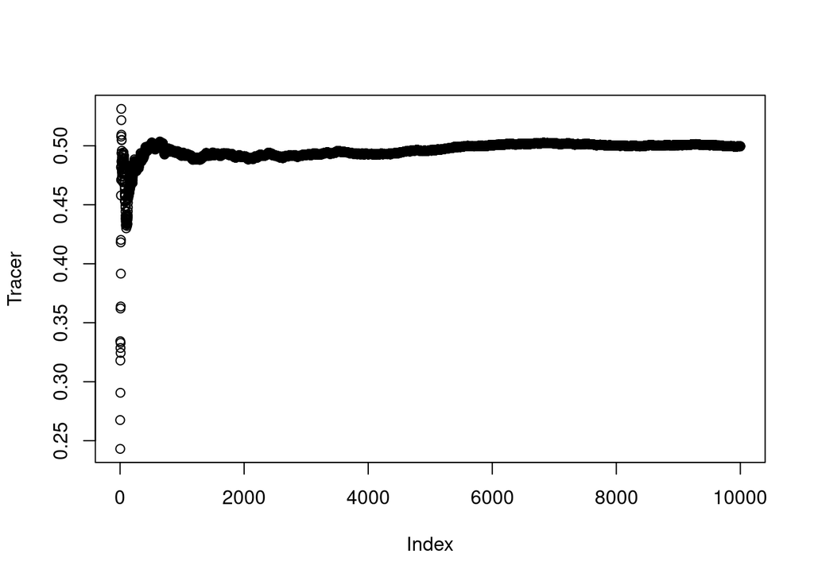

```r
plot(Tracer)
```

Here is another example of a custom function using a loop construct. This one is more interesting than the last. It provides astrological predictions!

```r
AdviseMeR <- function(birthdate)
{
  print(paste("Thank you for using R as your astrological guide. You have indicated that your birthdate is", birthdate), quote=FALSE)
  for (counter in 1:3)
  {
    print("Channeling celestial wisdom... ", quote=FALSE)
    Sys.sleep(time=2)
  }
  readline(prompt = "Celestial wisdom successfully channeled! Press any key to receive your predictions.")
  if (rnorm(n=1, mean=0, sd=1) > 0) {forecast <- "WONDERFUL"} else {forecast <- "MISERABLE"}
  print(paste("The stars indicate that your year ahead will be:",forecast), quote=FALSE)
}
```

Note: this function uses ‘Sys.sleep’ which causes a simple time delay (just for dramatic effect ;-)) and ‘readline’ which waits for user input before continuing.

Let’s test out our function:

```r
AdviseMeR("9 October 1980")
```

```
## [1] Thank you for using R as your astrological guide. You have indicated that your birthdate is 9 October 1980
## [1] Channeling celestial wisdom...
## [1] Channeling celestial wisdom...
## [1] Channeling celestial wisdom...
## Celestial wisdom successfully channeled! Press any key to receive your predictions.
## [1] The stars indicate that your year ahead will be: WONDERFUL
```

Our astrological guide function also demonstrated two very important programming features: (1) a ‘for’ loop, and (2) an ‘if’/‘else’ conditional gate. Spend a moment to study the code. Do you see how it works?

Using loops and gates, we can build up sophisticated multi-step algorithms. Other types of loops include ‘while’ loops, ‘repeat’ loops (which also require a ‘break’ point), and several others. Variations on the if/else gate include ‘ifelse’ and ‘switch’

You may not need these loops and gates to perform more basic analyses, but they can be extremely useful in data manipulation, along with the ‘apply’ function and its pals (‘tapply’, ‘sapply’, ‘lapply’ and ‘by’).

## Exercise 6

This exercise uses data from the ‘ldeaths’ dataset, which shows UK deaths from lung-related diseases (’74 - ’79).

Well… actually the original dataset is stored as class ‘ts’ (time series), which is kind of obscure and not what we’re after for this exercise. So… let’s just convert it to a data.frame before we proceed, using the code below. [For now, don’t worry about understanding this particular code chunk. It’s not the focus of this exercise.]

```r
ldeaths <- as.data.frame(cbind(1974:1979, matrix(datasets::ldeaths, ncol=12, nrow=6))); names(ldeaths) <- c("Year", month.abb[1:12]); ldeaths
```

```
##   Year  Jan  Feb  Mar  Apr  May  Jun  Jul  Aug  Sep  Oct  Nov  Dec
## 1 1974 3035 1721 2933 1607 2787 1489 3102 1498 2815 1529 3084 1461
## 2 1975 2552 1524 2889 1545 3891 1300 2294 1361 3137 1366 2605 1354
## 3 1976 2704 1596 2938 1396 3179 1356 2385 1346 2679 1357 2573 1333
## 4 1977 2554 2074 2497 1787 2011 1653 2444 1564 1969 1570 2143 1492
## 5 1978 2014 2199 1870 2076 1636 2013 1748 1640 1870 1535 1693 1781
## 6 1979 1655 2512 1726 2837 1580 2823 1554 2293 1633 2491 1504 1915
```

Right, let’s proceed.

6.1 The function below uses a ‘while’ loop to estimate the mortality, per calendar month, averaging across the 6-year span. Run the code chunk.

```r
Monthly.means <- function(Input)
{
  cumulative.totals <- ldeaths[1,2:13]
  counter <- 0
  while (counter < 6)
  {
    counter <- counter + 1
    cumulative.totals <- cumulative.totals + ldeaths[counter,2:13]
  }
  Monthly.means <- cumulative.totals / 6
  return(Monthly.means)
}
Monthly.means(ldeaths)
```

```
##        Jan    Feb      Mar    Apr    May    Jun    Jul      Aug      Sep
## 1 2924.833 2224.5 2964.333 2142.5 2978.5 2020.5 2771.5 1866.667 2819.667
##        Oct  Nov    Dec
## 1 1896.167 2781 1799.5
```

Currently, our function is currently producing a false result. Looking at the ‘January’ column of ‘ldeaths’, we had the values 3035, 2552, 2704, 2554, 2014 and 1655. The mean of these should be 2419 …

```r
mean(ldeaths[,'Jan'])
```

```
## [1] 2419
```

… but instead the function returns 2924.833. Can you see where the problem is?

6.2 The above code was actually a fairly awkward way of achieving our goal. Propose an alternative approach, perhaps using ‘apply’ or ‘sapply’.